# report_editable

Quick Scan

Engagement průzkum

Manažerský výstup

Co nás čeká

- 01 Průzkum v číslech
- 02 Výsledky engagementu
- 03 Výsledky jednotlivých driverů
- 04 Otázky, které dopadly hůře
- 05 Multiple choice otázky
- 06 Otevřené otázky
- 07 Závěrečná shrnutí a doporučení

01

Průzkum v číslech

Tato sekce poskytuje základní přehled o průběhu průzkumu ve firmě. Ukážeme Vám např. kolik zaměstnanců se průzkumu zúčastnilo celkově, za jednotlivé organizační jednotky nebo podle demografických údajů.

Průzkum v číslech

30 minut

trvalo průměrně vyplnění dotazníku.

379 lidí

ve vaší firmě odpovědělo na průzkum.

Respondenti podle oddělení

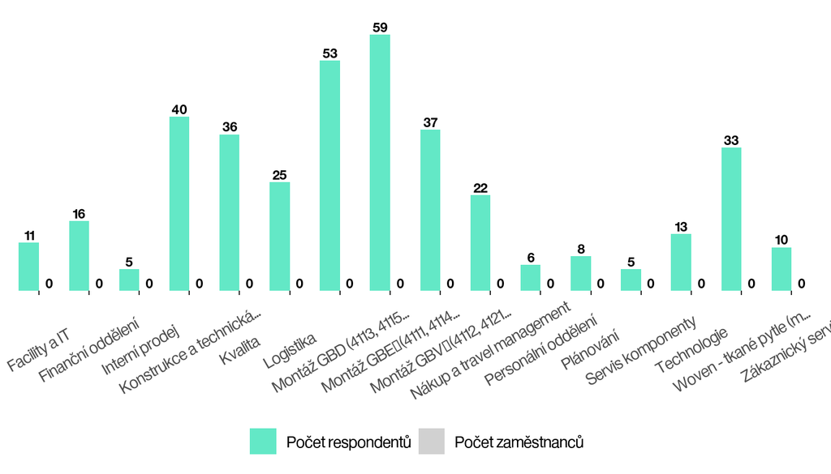

Respondenti podle věku

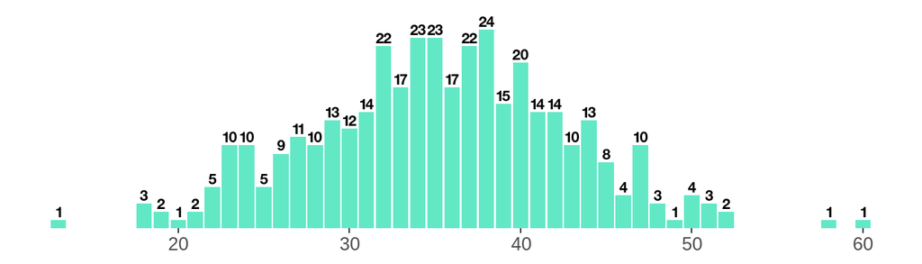

Pracovní pozice

[figure not shown]

Délka působení ve firmě

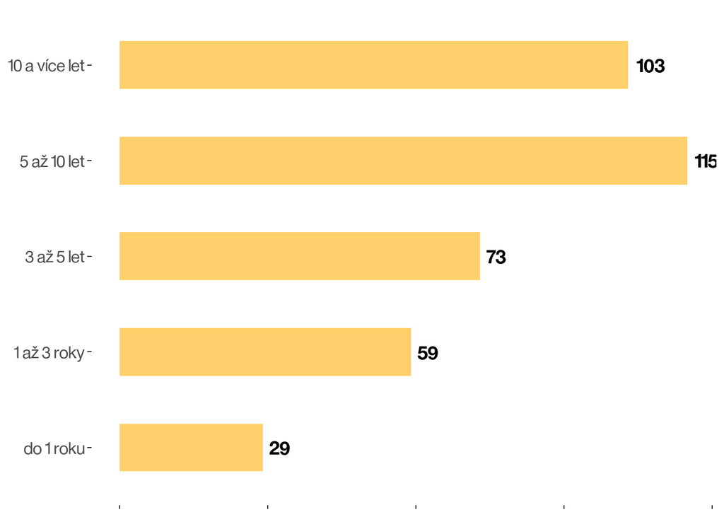

02

Výsledky engagementu

Engagement popisuje vztahy uvnitř firmy. Vztahy mezi zaměstnanci navzájem nebo zaměstnanců k jejich práci. Vyjadřuje, jak moc se člověk dokáže do své práce ponořit, jak pro svou práci/ firmu/kolegy udělá o krok navíc či jednoduše, jak moc jej práce baví a těší.

Engagement je komplexní téma. Právě proto jej měřímě pomocí dvou rozdílných metrik – Engagement indexu a Individuální míry engagementu. Výpočet obou metrik Vám dále vysvětlíme a odprezentujeme.

Metriky engagementu

Každá z engagementových metrik má svůj unikátní záměr, a vyžaduje tak vlastní výpočet i interpetaci. Sledováním Engagement indexu i Individuální míry engagementu získáte komplexnější vhled do celé problematiky a možnost odhalit potenciální problémy, které jeden samostatný ukazatel nedokáže odkrýt.

01

Engagement index

Engagement index je výchozí metrika engagementu v našich výstupech, a má za cíl zmapovat pocity zaměstnanců ohledně jednotlivých aspektů engagementu. Představuje výkon firmy napříč otázkami. Každá odpověď na dílčí otázku může ovlivnit celkovou úroveň engagementu, a proto se také za úplný engagement považuje pouze odpověď Určitě ano. Tato metrika je dále zkoumána napříč odděleními a senioritou zaměstnanců.

02

Individuální míra engagementu

Individuální míra engagementu se zaměřuje na každého zaměstnance zvlášť. Konkrétně na to, jak si vede napříč všemi aspekty engagementu. U každého respondenta se zprůměrují odpovědi na engagementové otázky, a podle toho se zařadí do jedné ze tří skupin – fully engaged, partially engaged nebo disengaged. Na úrovni firmy je důležité sledovat, jaké jsou proporce jednotlivých skupin zaměstnanců a zda se mění v čase.

03

Net promoter score (NPS)

Net promoter score sleduje jednu věc – nakolik je daný zaměstnanec dobrým ambasadorem firmy. Ochota aktivně propagovat svou firmu jako dobré místo pro práci je silně asociovaná i s ostatními aspekty engagementu, a tak skvěle doplňuje obrázek o stavu engagementu ve firmě. Net promoter score dle odpovědi na otázku Doporučil(a) bych tuto firmu jako zaměstnavatele dělí zaměstnance na tři typy – active promoters, neutrals a active detractors.

Jak cist?

Engagement index

Engagement index za firmu

Uplny engagement

42 %

Uplny engagement za firmu = 42 %. Toto cislo vyznacuje, kolik % odpovedi na vsechny engagementove otazky bylo urcite ano.

Castecny engagement

33 %

Slaby engagement

25 %

Engagement index pro otazku

Skala odpovedi

Urcite ano = skore 1

Spise ano = skore 2

Nemohu se rozhodnout = skore 3

Spise ne = skore 4

Urcite ne = skore 5

Jak cist?

Individualni mira engagementu

Individualni mira engagementu

Uplny engagement

42 %

Castecny engagement

33 %

Slaby engagement

25 %

Priklad:

Respondent odpovedel na engagementove otazky:  
*Urcite ano, Urcite ano, Spise ano, Spise ano.*

Skala odpovedi

Urcite ano = skore 1

Spise ano = skore 2

Nemohu se rozhodnout = skore 3

Spise ne = skore 4

Urcite ne = skore 5

Vysledky

# Engagement index za firmu

v porovnani s benchmarky

Engagement index za firmu

Uplny engagement

42 %

Uplny engagement reflektuje velmi dobrou atmosferu uvnitr firmy a kladny vztah zamestnancu k praci i firme. Za dobrou naladou muze stat skupina velmi spokojenych zamestnancu, nebo plosna spokojenost s nekterymi aspekty prace a firemni kultury.

Castecny engagement

33 %

Castecny engagement ukazuje na dilci nedostatky, v nichz spociva potencial firmy pro zlepseni. Klicove je pochopit, zda za vysledky stoji skupina zamestnancu nebo vysledky nekterych z konkretnich engagementovych otazek. Kompletni obrazek se ziska srovnanim s individualni mirou engagementu.

Slaby engagement

25 %

Slaby engagement indikuje spatnou atmosferu, ktera muze vest az k odchodu nekterych zamestnancu. Opet je dulezite urcit, zda slaby vysledek ukazuje na skupinu zamestnancu nebo na plosnou nespokojenost s nekterymi aspekty prace. Ke spravnemu vyhodnoceni je dobre porovnat tento vysledek s individualni mirou engagementu.

International benchmark

CZECH REPUBLIC

32 %

U.S.

37 %

WHM

Skala odpovedi

Urcite ano = skore 1

Spise ano = skore 2

Nemohu se rozhodnout = skore 3

Spise ne = skore 4

Urcite ne = skore 5

Vysledky

# Engagement index za firmu

Engagement se meril nasledujicimi otazkami:

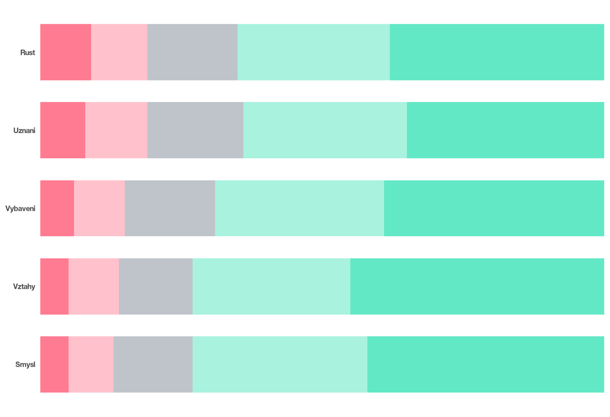

Skala odpovedi

Urcite ano = skore 1

Spise ano = skore 2

Nemohu se rozhodnout = skore 3

Spise ne = skore 4

Urcite ne = skore 5

Vysledky

# Individualni mira engagementu za firmu

Uplny engagement

42 %

Do kategorie fully engaged spadaji lide, kteri pracuji naplno, svoji praci maji radi a zaroven maji radi sveho zamestnavatele.

Castecny engagement

33 %

V kategorii castecny engagement jsou lide, kteri maji radi svoji firmu, ale obcas jim neco nevyhovuje. Z toho duvodu je take jejich vykon promenlivy a ne tak stabilni. Zaroven tato kategorie predstavuje nejvetsi potencial pro rust a firma s ni muze dobre do budoucna pracovat.

Slaby engagement

25 %

Zde jsou lide, kteri k firme a tomu, co v ni delaji, maji maly nebo zadny vztah. Mohou zvazovat odchod nebo zmenu zamestnani. Jejich pracovni nasazeni je male a mohou ve svem okoli sirit negativni naladu.

Engagement index podle oddeleni

Detailni pohled pomaha odhalit tymy, ktere jsou vyrazne nadprumerne nebo naopak potrebují podporu.

[figure not shown]

Engagement index podle oddeleni

Srovnani napric oddelenimi ukazuje, kde se nejvice propisuje kvalita vedeni, smyslu prace nebo spoluprace.

[figure not shown]

Engagement index podle oddeleni

Na teto urovni uz lze dobre cist, ktere tymy stoji za hlubsi interpretaci v kontextu organizacnich zmen nebo managerske praxe.

[figure not shown]

Vysledky

# Srovnani engagementu indexu napric oddelenimi

Minuly rokAktualni rok

100 %

15 %

10 %

100 %

15 %

Minuly rokAktualni rok

10 %

100 %

15 %

10 %

100 %

15 %

Minuly rokAktualni rok

10 %

100 %

15 %

10 %

100 %

15 %

Minuly rokAktualni rok

10 %

100 %

15 %

10 %

100 %

15 %

Minuly rokAktualni rok

10 %

100 %

15 %

10 %

100 %

15 %

>>

Skala odpovedi

Fully engaged

Partially engaged

Disengaged

Vysledky

# Srovnani engagementu indexu napric oddelenimi

Minuly rokAktualni rok

10 %

100 %

15 %

10 %

100 %

15 %

Minuly rokAktualni rok

10 %

100 %

15 %

10 %

100 %

15 %

Minuly rokAktualni rok

10 %

100 %

15 %

10 %

100 %

15 %

Skala odpovedi

Fully engaged

Partially engaged

Disengaged

Vysledky

# Srovnani individualni miry engagementu napric oddelenimi

Aktualni rok

10 %

100 %

15 %

Aktualni rok

10 %

100 %

15 %

Aktualni rok

10 %

100 %

15 %

Aktualni rok

10 %

100 %

15 %

Aktualni rok

10 %

100 %

15 %

Skala odpovedi

Fully engaged

Partially engaged

Disengaged

03

Výsledky klíčových driverů

Engagement neexistuje ve vakuu. Výsledky engagementu mohou být značně ovlivněny různými klíčovými tématy, tzv. drivery engagementu. Moduly zařazené do průzkumu jsou aktuálními daty podložené významné drivery engagementu.

Měřené/sledované drivery

Díky neustálému sledování trendů v oblasti engagementu a analýze našich dat jsme vybrali moduly, které jsou podle nás nejvýznamnějšími drivery engagementu. Pojďme si je teď podrobněji představit

Já a firma

Znalost toho, kam firma jde, jakou má za sebou historii a co od ní tím pádem mohu čekat. Bez dobré znalosti toho, jaký je firemní vývoj, se zaměstnanec nemůže s firmou spojit a nemůže být hrdý na to, že je její součástí. Dále se zaměřujeme na znalost firemních cílů, abychom znali povědomí zaměstnanců o budoucím firemním směřování.

Já a tým

Kvalita spolupráce uvnitř týmu, důvěra mezi kolegy a schopnost společně řešit chyby či překážky. Tento driver ukazuje, nakolik zaměstnanci zažívají bezpečné a podporující pracovní prostředí.

Já a vedoucí

Srozumitelnost zadání, kvalita zpětné vazby a každodenní podpora od přímého nadřízeného. Sledujeme, zda vedoucí pomáhá vytvářet podmínky pro kvalitní práci i dlouhodobou motivaci.

Rozvoj a růst

Možnosti učit se nové věci, posouvat se profesně a vidět ve firmě další perspektivu. Právě pocit rozvoje často rozhoduje o tom, zda si zaměstnanec s firmou dokáže spojit i svou budoucnost.

Nástroje a podmínky

To, zda mají lidé k dispozici funkční procesy, vybavení a podmínky pro dobrou práci. Pokud tato oblast nefunguje, negativně ovlivňuje nejen výkon, ale i celkový pracovní zážitek zaměstnanců.

Prezentace driveru

Data z modulu prezentujeme na ctyrech urovnich detailu, od **obecnych souhrnu az po podrobne analyzy.**

**Prvni dve urovne** **(Obecny souhrn)** se zameruji na odpovedi agregovane do sirsich kategorii (skvely, prumerny, slaby vysledek). Agregovane odpovedi nejprve porovnavame s externimi benchmarky a pote zmapujeme situaci uvnitr firmy.

**Dalsi dve urovne** **(Podrobne analyzy)** se zameruji na detailni rozlozeni odpovedi. Na treti urovni uvidite procentualni podil odpovedi na kazdou otazku - od „Urcite ano“ po „Urcite ne“ - na urovni cele firmy. Ctvrta uroven pak ukaze, jak se odpovedi rozdeluji mezi jednotlive organizacni jednotky. S kazdym krokem ziskate hlubsi prehled o deni ve firme.

Obecny souhrn

Podrobne analyzy

Agregace:

**Skvely vysledek** = Urcite ano a Spise ano,  
**Prumerny vysledek** = Nemohu se rozhodnout,  
**Slaby vysledek** = Urcite ne, Spise ne

Agregace:

Urcite ano - Spise ano - Nemohu se rozhodnout - Spise ne - Urcite ne

1.

Srovnani s benchmarky

2.

Drivery za firmu

3.

Detail otazek

4.

Drivery v detailu za organizacni jednotku

Jak cist?

Srovnani driveru s relevantnimi benchmarky

?

?

Czech Republic

UK

Engagement

81 %

78 %

88 %

Leadership

78 %

98 %

78 %

Values

87 %

63 %

78 %

Share

67 %

88 %

76 %

Respondentu

203

30

Jak cist?

Vysledky driveru za firmu

?

?

?

Podil odpovedi **Urcite ano**  
a **Spise ano** na vsech odpovedich driveru

100 %

Podil odpovedi **Nemohu se rozhodnout** na vsech odpovedich driveru

10 %

Podil odpovedi **Urcite ne**  
a **Spise ne** na vsech odpovedich driveru

Podil odpovedi **Urcite ano a Spise ano**  
na vsech za danou otazku

88 % Mam dobry vztah se svym vedoucim.

88 % V pracovnich otazkach me vedouci vzdy vyslysi a da prostor k vyjadreni.

88 % Dostavam pravidelnou zpetnou vazbu od meho vedouciho.

Skala odpovedi

Urcite ano = skore 1

Spise ano = skore 2

Nemohu se rozhodnout = skore 3

Spise ne = skore 4

Urcite ne = skore 5

Jak cist?

Detail otazky

?

?

?

88 %

88 %

88 %

88 %

88 %

88 %

88 %

88 %

88 %

88 %

Podil odpovedi **Urcite ano** na danou otazku

Podil odpovedi **Spise ano** na danou otazku

Podil odpovedi **Nemohu se rozhodnout** na danou otazku

Podil odpovedi **Spise ne** na danou otazku

Podil odpovedi **Urcite ne** na danou otazku

Skala odpovedi

Urcite ano = skore 1

Spise ano = skore 2

Nemohu se rozhodnout = skore 3

Spise ne = skore 4

Urcite ne = skore 5

Merene/sledovane drivery

Diky neustalemu sledovani trendu v oblasti engagementu a analyze nasich dat jsme vybrali moduly, ktere jsou podle nas nejvyznamnejsimi drivery engagementu. Pojdme si je ted podrobneji predstavit

Ja a firma

Znalost toho, kam firma jde, jakou ma za sebou historii a co od ni tim padem mohu cekat. Bez dobre znalosti toho, jaky je firemni vyvoj, se zamestnanec nemuze s firmou spojit a nemuze byt hrdy na to, ze je jeji soucasti. Dale se zamerujeme na znalost firemnich cilu, abychom znali povedomi zamestnancu o budoucim firemnim smerovani.

Prezentace driveru

Data z modulu prezentujeme na ctyrech urovnich detailu, od **obecnych souhrnu az po podrobne analyzy.**

**Prvni dve urovne** **(Obecny souhrn)** se zameruji na odpovedi agregovane do sirsich kategorii (skvely, prumerny, slaby vysledek). Agregovane odpovedi nejprve porovnavame s externimi benchmarky a pote zmapujeme situaci uvnitr firmy.

**Dalsi dve urovne** **(Podrobne analyzy)** se zameruji na detailni rozlozeni odpovedi. Na treti urovni uvidite procentualni podil odpovedi na kazdou otazku - od „Urcite ano“ po „Urcite ne“ - na urovni cele firmy. Ctvrta uroven pak ukaze, jak se odpovedi rozdeluji mezi jednotlive organizacni jednotky. S kazdym krokem ziskate hlubsi prehled o deni ve firme.

Obecny souhrn

Podrobne analyzy

Agregace:

**Skvely vysledek** = Urcite ano a Spise ano,  
**Prumerny vysledek** = Nemohu se rozhodnout,  
**Slaby vysledek** = Urcite ne, Spise ne

Agregace:

Urcite ano - Spise ano - Nemohu se rozhodnout - Spise ne - Urcite ne

1. Srovnani s benchmarky

2. Drivery za firmu

3. Detail otazek

4. Drivery v detailu za organizacni jednotku

Jak cist vysledky driveru

Kazdy driver posuzujeme ze dvou uhlu. Sledujeme, jak silne souvisi s engagementem a zaroven jak pozitivne nebo negativne jej zamestnanci hodnoti.

Sila vztahu

Jak moc driver ovlivnuje engagement

Vyssi hodnota znamena, ze posun v dane oblasti se s velkou pravdepodobnosti promita i do celkoveho engagementu.

Aktualni skore

Jak si firma v dane oblasti vede

Nizsi hodnoceni ukazuje, ze zamestnanci tuto oblast casto zazivaji mene pozitivne a muze jit o dulezitou prioritu.

Jak cist? Drivery a benchmark

Kombinace sily vztahu a aktualniho skore pomaha rozlisit, ktere oblasti jsou strategicky nejdulezitejsi a kde firma ztraci oproti trhu.

Vysoka priorita

Silny vliv na engagement a soucasne slabe skore.

Udrzet

Silny vliv a soucasne dobre vysledky.

Monitorovat

Slabsi vliv, ale horsi skore nez benchmark.

Sekundarni fokus

Slabsi vliv a zaroven prijatelne vysledky.

Jak cist? Drivery celkem

Na souhrnnem slidu se kombinuje informace o sile vztahu s engagementem a o tom, jak si firma v danem driveru skutecne stoji.

Nejvyse postavene drivery by mely vstupovat do prioritizace akcnich kroku jako prvni, zejmena pokud zaroven nedosahuji silneho skore.

68 %

Rozvoj a rust drzi stred pole. Pokud je vsak dlouhodobe slabsi, muze brzdit udrzeni talentu i vnitrni motivaci.

Vysvetlivka

Silne skore

Spise silne

Neutralni

Spise slabe

Slabe

Vysledky

Drivery za firmu

Top 3

Bottom 3

Ja a firma

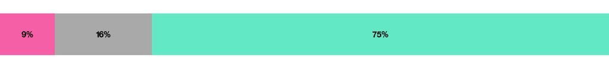

64 %Znam firemni cile.

71 %Pro tuto firmu je rozhodne dobre pracovat.

89 %Pracovni prostredi je bez sikany a obtezovani.

75 %Doporucuji tuto firmu jako zamestnavatele.

Ja a vedouci

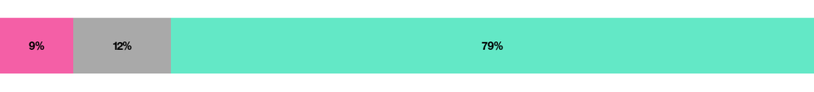

79 %Muj vedouci mi zadava ukoly jasne a presne.

89 %Mam dobry vztah se svym vedoucim.

85 %V pracovnich otazkach me vedouci vzdy vyslysi a da prostor k vyjadreni.

70 %Dostavam pravidelnou zpetnou vazbu od meho vedouciho.

73 %Dostavam realnou podporu od sveho vedouciho.

Ja a tym

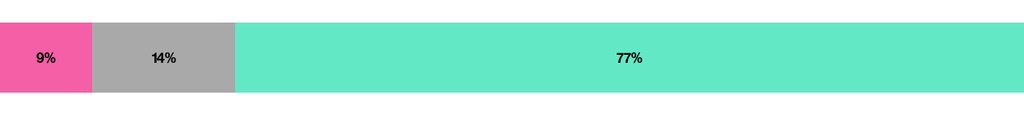

85 %Svym kolegum/kolegynim duveruji.

88 %Ja a kolegove z meho oddeleni resime problemy tak, aby se jiz neopakovaly.

85 %Na mem oddeleni se dokazeme bavit o chybach a efektivne je resit.

83 %Cile meho oddeleni jsou mi jasne.

45 %Me oddeleni dostava dostatecnou podporu od oddeleni, se kterymi spolupracujeme.

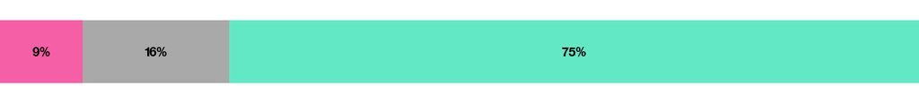

64 %Znam firemni cile.

71 %Pro tuto firmu je rozhodne dobre pracovat.

89 %Pracovni prostredi je bez sikany a obtezovani.

75 %Doporucuji tuto firmu jako zamestnavatele.

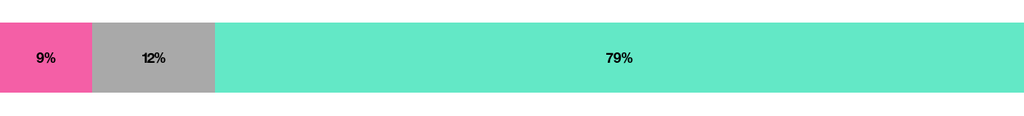

79 %Muj vedouci mi zadava ukoly jasne a presne.

89 %Mam dobry vztah se svym vedoucim.

85 %V pracovnich otazkach me vedouci vzdy vyslysi a da prostor k vyjadreni.

70 %Dostavam pravidelnou zpetnou vazbu od meho vedouciho.

73 %Dostavam realnou podporu od sveho vedouciho.

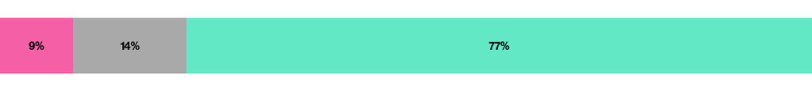

85 %Svym kolegum/kolegynim duveruji.

88 %Ja a kolegove z meho oddeleni resime problemy tak, aby se jiz neopakovaly.

85 %Na mem oddeleni se dokazeme bavit o chybach a efektivne je resit.

83 %Cile meho oddeleni jsou mi jasne.

45 %Me oddeleni dostava dostatecnou podporu od oddeleni, se kterymi spolupracujeme.

Vysledky

Driver 1/5 - Detailne

[figure not shown]

Skala odpovedi

Urcite ano = skore 1

Spise ano = skore 2

Nemohu se rozhodnout = skore 3

Spise ne = skore 4

Urcite ne = skore 5

Vysledky

Driver 1/5 - Detailne - urcite ano srovnani dle oddeleni

[figure not shown]

Skala odpovedi

Mira spokojenosti oddeleni

Mira spokojenosti za firmu

04

Problematicke otazky

Vysledky

Rozpad problematicke otazky 1 dle oddeleni

[figure not shown]

Skala odpovedi

Skvely vysledek

Prumerny vysledek

Spatny vysledek

Vysledky

[figure not shown]

Skala odpovedi

Skvely vysledek

Prumerny vysledek

Spatny vysledek

05

Multiple choice otazky

Ne vsechny otazky jsou hodnocene na skale od Urcite ano po Urcite ne. V nekterych otazkach rovnez zkoumame preference respondentu s moznosti vybrat vice odpovedi. Tem je venovana nasledujici sekce.

Jak cist?

Multiple choice otazky

?

?

?

1/3 = 33 %

Tuto moznost preferuje  
**33 %** respondentu

[figure not shown]

Vysledky

Srovnani odpovedi na multiple choice otazku

[figure not shown]